# Practicum II / Part B

DA5030 / Multiple Linear Regression

Larkin, Yvonne

Fall 2025 / November 2025

# PART B : Target `DONATION_AMT`

## 1. Load Packages

```r
# packages
library(ggplot2)
library(knitr)
library(caret)
library(psych)
```

## 1.1 Load Data

Extracted data file `donations-salted.csv` from the compressed file linked donations-salted.csv.zip to locally load data to a data.frame in the R Project. The file has headers, is comma delimited, and has both `numeric` and `character` string class data entries. Use `read.csv( )` to load file into a data.frame `df`.

There are only 4 `character` features and 1 `logical` features that would be affected by `stringsAsFactors`, but I will load the data with the parameter `FALSE` to allow for viewing the file as is, avoid the need to undo any factor leveling, and have more control proceeding. I did explore both `TRUE` and `FALSE` loading, overall I think that avoiding the need to change factor levels is easier than starting with them. Especially for ordinal features.

```r
# load file to df
df <- df.backup <- read.csv("donations-salted.csv",
               header = TRUE,
               stringsAsFactors = FALSE)

# confirm df load
head(df, 3)
```

|  | CONTROL_NUMBER | DONATED | DONATION_AMT | DONOR_AGE | URBANICITY | DONOR_GENDER | HOME_OWNER | INCOME_LEVEL | SES | MEDIAN_HOME_VALUE | MEDIAN_HOUSEHOLD_INCOME | DONATION_RESPONSE | MONTHS_SINCE_LAST_GIFT | EMAILS_12 | LIFETIME_GIFT_COUNT | LIFETIME_EMAILS | LIFETIME_GIFT_AMOUNT | LIFETIME_MAX_GIFT_AMT | LIFETIME_MIN_GIFT_AMT | LIFETIME_AVG_GIFT_AMT |
| --- | --- | --- | --- | --- | --- | --- | --- | --- | --- | --- | --- | --- | --- | --- | --- | --- | --- | --- | --- | --- |
| 1 | 5 | FALSE | NA | 87 | ? | M | H | 2 | . | 554000 | 294000 | 0 | 26 | 17 | 35 | 19 | 29700 | 2000 | 500 | 849 |
| 2 | 12 | TRUE | 1000 | 79 | R | M | H | 7 | 45 | 334000 | 212000 | 0 | 7 | 28 | 25 | 32 | 36800 | 2500 | 500 | 1472 |
| 3 | 37 | FALSE | NA | 75 | S | F | H | 5 | 11 | 2388000 | 405000 | 0 | 6 | 43 | 36 | 44 | 60300 | 2800 | 500 | 1675 |

### 1.2 Brief EDA with `str()` and `summary()`

```r
str(df)
```

```
## 'data.frame':    19372 obs. of  20 variables:
##  $ CONTROL_NUMBER         : int  5 12 37 38 41 52 53 67 70 71 ...
##  $ DONATED                : logi  FALSE TRUE FALSE FALSE FALSE FALSE ...
##  $ DONATION_AMT           : int  NA 1000 NA NA NA NA NA 500 NA 1600 ...
##  $ DONOR_AGE              : int  87 79 75 NA 74 63 71 79 41 63 ...
##  $ URBANICITY             : chr  "?" "R" "S" "U" ...
##  $ DONOR_GENDER           : chr  "M" "M" "F" "F" ...
##  $ HOME_OWNER             : chr  "H" "H" "H" "H" ...
##  $ INCOME_LEVEL           : int  2 7 5 6 2 3 5 1 4 4 ...
##  $ SES                    : chr  "." "45" "11" "4" ...
##  $ MEDIAN_HOME_VALUE      : num  554000 334000 2388000 1688000 514000 ...
##  $ MEDIAN_HOUSEHOLD_INCOME: num  294000 212000 405000 153000 328000 182000 122000 189000 180000 307000 ...
##  $ DONATION_RESPONSE      : int  0 0 0 0 8 0 0 0 0 0 ...
##  $ MONTHS_SINCE_LAST_GIFT : int  26 7 6 6 18 19 21 9 17 9 ...
##  $ EMAILS_12              : int  17 28 43 44 25 29 25 33 36 38 ...
##  $ LIFETIME_GIFT_COUNT    : int  35 25 36 37 12 22 20 20 34 22 ...
##  $ LIFETIME_EMAILS        : int  19 32 44 31 30 22 29 33 36 27 ...
##  $ LIFETIME_GIFT_AMOUNT   : num  29700 36800 60300 43500 10600 12800 22000 10100 17100 15000 ...
##  $ LIFETIME_MAX_GIFT_AMT  : num  2000 2500 2800 1700 2500 1000 2000 700 700 1100 ...
##  $ LIFETIME_MIN_GIFT_AMT  : int  500 500 500 300 500 300 500 300 300 300 ...
##  $ LIFETIME_AVG_GIFT_AMT  : int  849 1472 1675 1176 883 582 1100 505 503 682 ...
```

```r
summary(df)
```

```
##  CONTROL_NUMBER    DONATED         DONATION_AMT     DONOR_AGE
##  Min.   :     5   Mode :logical   Min.   :  100   Min.   : 0.00
##  1st Qu.: 48289   FALSE:14529     1st Qu.: 1000   1st Qu.:47.00
##  Median : 96937   TRUE :4843      Median : 1300   Median :60.00
##  Mean   : 96546                   Mean   : 1562   Mean   :58.92
##  3rd Qu.:145430                   3rd Qu.: 2000   3rd Qu.:73.00
##  Max.   :191779                   Max.   :20000   Max.   :87.00
##                                   NA's   :14529   NA's   :4795
##   URBANICITY        DONOR_GENDER        HOME_OWNER         INCOME_LEVEL
##  Length:19372       Length:19372       Length:19372       Min.   :1.000
##  Class :character   Class :character   Class :character   1st Qu.:2.000
##  Mode  :character   Mode  :character   Mode  :character   Median :4.000
##                                                           Mean   :3.908
##                                                           3rd Qu.:5.000
##                                                           Max.   :7.000
##                                                           NA's   :4392
##      SES            MEDIAN_HOME_VALUE MEDIAN_HOUSEHOLD_INCOME DONATION_RESPONSE
##  Length:19372       Min.   :      0   Min.   :      0         Min.   :  0.000
##  Class :character   1st Qu.: 518000   1st Qu.: 232000         1st Qu.:  0.000
##  Mode  :character   Median : 747000   Median : 311000         Median :  0.000
##                     Mean   :1079872   Mean   : 341970         Mean   :  3.362
##                     3rd Qu.:1227000   3rd Qu.: 417000         3rd Qu.:  3.000
##                     Max.   :6000000   Max.   :1500000         Max.   :241.000
##
##  MONTHS_SINCE_LAST_GIFT   EMAILS_12     LIFETIME_GIFT_COUNT LIFETIME_EMAILS
##  Min.   : 4.00          Min.   : 2.00   Min.   : 1.00       Min.   : 2.00
##  1st Qu.:16.00          1st Qu.:16.00   1st Qu.: 4.00       1st Qu.:11.00
##  Median :18.00          Median :18.00   Median : 8.00       Median :18.00
##  Mean   :18.19          Mean   :18.27   Mean   : 9.98       Mean   :18.67
##  3rd Qu.:20.00          3rd Qu.:19.00   3rd Qu.:14.00       3rd Qu.:26.00
##  Max.   :27.00          Max.   :77.00   Max.   :95.00       Max.   :56.00
##
##  LIFETIME_GIFT_AMOUNT LIFETIME_MAX_GIFT_AMT LIFETIME_MIN_GIFT_AMT
##  Min.   :  1500       Min.   :   500        Min.   :    0.0
##  1st Qu.:  4200       1st Qu.:  1200        1st Qu.:  300.0
##  Median :  7900       Median :  1600        Median :  500.0
##  Mean   : 10443       Mean   :  1921        Mean   :  762.1
##  3rd Qu.: 13200       3rd Qu.:  2100        3rd Qu.: 1000.0
##  Max.   :377500       Max.   :100000        Max.   :45000.0
##
##  LIFETIME_AVG_GIFT_AMT
##  Min.   :  136
##  1st Qu.:  800
##  Median : 1120
##  Mean   : 1286
##  3rd Qu.: 1500
##  Max.   :45000
##
```

## 2. Dataset Information

### 2.1 Background Information Explicitly Provided or Derived from Following Resources:

1. Professor Schedlbauer’s [Donations Data Dictionary](https://s3.us-east-2.amazonaws.com/artificium.us/datasets/meta-data/donations/donations-salted-meta.html) for explicit list and code notes.
   - which provided link to bullet #2
2. [Donors-Prediction Data on Kaggle Cite](https://www.kaggle.com/datasets/momohmustapha/donorsprediction/data)
   - ‘Discussion’ Tab provided link to bullet #3
3. [Dropbox by Dataset Owner Mustapha Unubi Momoh](https://www.dropbox.com/sh/7jcfj23mjz0uvvc/AABojZ0vMvWjiw1gvSHGOZFha?dl=0)

#### 2.2 Donor Feature Dictionary

Important Note: All donors in the data set have made at least 1 donation.  
$\text{"donation"} == \text{"gift"}$ ; where $\text{donation} > 0$ by definition

### 2.3 Remove Unneeded Features

Based on the “DONOR” Data Dictionary, there are definitions for categorical and numeric features. Additionally, it indicates the direct relation of `DONOR` and `DONATION_AMT` so these are not predictors of each other, similar to how Part A had `DONATION_AMT` removed , the same will happen for this part along with `CONTROL_AMT` a completely independent ID number.

#### 2.3.1 Remove Part A Target `DONATED`

This can be used to at least set a 0 if the ‘DONATION_AMT’ is `NA` but also `FALSE` `DONATION_AMT` : is the quantitative evaluation of a monetary donation made/gifted. If no donation was made value, corresponding to `DONATED` `FALSE`, this indicates it is `0`. This is a feature that is resultant of the target feature `DONATED` being `TRUE`.

```r
test_forFALSE <- df[which(isFALSE(df$DONATED) && is.na(df$DONATION_AMT)),]
if(nrow(test_forFALSE) == 0){
  cat("There are no observations that have both :\n\n")
  cat("`DONATION_AMT` == `NA`&& `DONATED` == `FALSE`\n")
  test_forFALSE <- df[which(isFALSE(df$DONATED) && df$DONATION_AMT > 0),]

  if(nrow(test_forFALSE) == 0){
    cat("OR\n`DONATION_AMT` > 0 && `DONATED` == `FALSE`")
  }
} else {
  cat("There is a contradiction in `DONATED` and `DONATION_AMT` , look into it")
}
```

[output not shown]

#### 2.3.2 Removed `CONTROL_NUMBER`

`CONTROL_NUMBER` : unique ID : There are as many unique IDs (19372) as there are observations (19372). This feature is completely independent from a donor’s other attributes/features, including whether or not an individual made a donation in the most recent campaign. It could potentially serves as a look-up value to identify distinct donors. However, the row index could serve this same purpose if order preserved.

```r
df <- df[,-which(colnames(df) %in% c('CONTROL_NUMBER', 'DONATED'))]
```

### 2.4 Separate Feature Types by DONOR Data Definitions

```r
donor_numeric_name <- c('DONATION_AMT', 'DONOR_AGE', 'MEDIAN_HOME_VALUE', 'MEDIAN_HOUSEHOLD_INCOME', 'DONATION_RESPONSE', 'MONTHS_SINCE_LAST_GIFT', 'EMAILS_12', 'LIFETIME_GIFT_COUNT', 'LIFETIME_EMAILS', 'LIFETIME_GIFT_AMOUNT', 'LIFETIME_MAX_GIFT_AMT', 'LIFETIME_MIN_GIFT_AMT', 'LIFETIME_AVG_GIFT_AMT')
donor_numeric_index <- which(colnames(df) %in% donor_numeric_name)

donor_categoric_name <- c('URBANICITY', 'DONOR_GENDER', 'HOME_OWNER', 'INCOME_LEVEL', 'SES')
donor_categoric_index <- which(colnames(df) %in% donor_numeric_name)
```

## Data Wrangling

From the basic `str()` and `summary()` , the data clearly has many `NA` values, speccial character uses, a wide range of values, and most unfortunately a large portion of the Target feature data missing from the ‘donations-salted.csv’ DONOR Data’s csv file. feature structure and meaning have been assessed. A deeper look into missing values, outliers, distribution, and correlation need to be evaluated to clean up the data to be uniform and complete for use in multiple linear regression, if there are too many features entries missing, the need to delete listwise may arise.

## 3. Identify Outliers

### 3.1 starting mean with `na.rm = T`

```r
df_num <- df[,donor_categoric_index]
df.mean <- sapply(df_num, mean, na.rm = T)
cat("Average value in Feature : \n")
```

```
## Average value in Feature :
```

```r
print(round(df.mean))
```

```
##            DONATION_AMT               DONOR_AGE       MEDIAN_HOME_VALUE
##                    1562                      59                 1079872
## MEDIAN_HOUSEHOLD_INCOME       DONATION_RESPONSE  MONTHS_SINCE_LAST_GIFT
##                  341970                       3                      18
##               EMAILS_12     LIFETIME_GIFT_COUNT         LIFETIME_EMAILS
##                      18                      10                      19
##    LIFETIME_GIFT_AMOUNT   LIFETIME_MAX_GIFT_AMT   LIFETIME_MIN_GIFT_AMT
##                   10443                    1921                     762
##   LIFETIME_AVG_GIFT_AMT
##                    1286
```

### 3.2 Calculate Z-score value to define outliers

$$\text{z-Score} = \frac{\text{X} - \mu
}{sd}$$
From the `summary()` it is already apparent that there are outliers present in multiple categories, but from some plotting in the R consol IDE it was apparent that extreme values were present and some lines in `LIFETIME` features count be infered, but for the majority it is a high density and wide spread of points polotted. Left leaning tails aren’t strongly defined so the change of a log_2 transformation causing a strong linear pattern is unlikely. But for now we’ll identify Outliers, missing values, and impute values.

```r
df.zScr <- df_num
df.zScr <- as.data.frame(lapply(df_num, function(x){
  col.mean <- mean(x, na.rm = T)
  col.sd <-sd(x, na.rm = T)
  col.zScr <- ifelse(!is.na(x), (x - col.mean)/col.sd, NA)
  return(col.zScr)
}))
# confirm correct results
head(df.zScr, 5)
```

|  | DONATION_AMT | DONOR_AGE | MEDIAN_HOME_VALUE | MEDIAN_HOUSEHOLD_INCOME | DONATION_RESPONSE | MONTHS_SINCE_LAST_GIFT | EMAILS_12 | LIFETIME_GIFT_COUNT | LIFETIME_EMAILS | LIFETIME_GIFT_AMOUNT | LIFETIME_MAX_GIFT_AMT | LIFETIME_MIN_GIFT_AMT | LIFETIME_AVG_GIFT_AMT |
| --- | --- | --- | --- | --- | --- | --- | --- | --- | --- | --- | --- | --- | --- |
| 1 | NA | 1.6845825 | -0.5473537 | -0.29213114 | -0.3537289 | 1.93620688 | -0.2289937 | 2.8798072 | 0.03878151 | 1.82150778 | 0.04913891 | -0.3292717 | -0.4970936 |
| 2 | -0.4519311 | 1.2046607 | -0.7763406 | -0.79149839 | -0.3537289 | -2.77485058 | 1.7559846 | 1.7288160 | 1.55768990 | 2.49307748 | 0.35967617 | -0.3292717 | 0.2118472 |
| 3 | NA | 0.9646998 | 1.3615648 | 0.38384159 | -0.3537289 | -3.02280097 | 4.4627731 | 2.9949064 | 2.95975919 | 4.71587857 | 0.54599852 | -0.3292717 | 0.4428504 |
| 4 | NA | NA | 0.6329700 | -1.15079921 | -0.3537289 | -3.02280097 | 4.6432257 | 3.1100055 | 1.44085080 | 3.12681226 | -0.13718344 | -0.5805348 | -0.1249850 |
| 5 | NA | 0.9047095 | -0.5889877 | -0.08507643 | 0.4880679 | -0.04739626 | 1.2146269 | 0.2325273 | 1.32401169 | 0.01489072 | 0.35967617 | -0.3292717 | -0.4584034 |

### 3.3 Number of Outliers by Column

```r
# store outlier index for later
outliers <- vector('list')
outlier_values <- vector('list')

for (col in colnames(df.zScr)) {
  # Find outliers where |z| > 3 for a base eval df.zScr
  z_Sc <- df.zScr[[col]]
  idx <- which(abs(z_Sc) > 3)
  if(length(idx) > 0){
    cat(col, " has : \n")
    cat("\t", length(idx), " outliers with z-score > |3.0|\n")

    # save index
    outliers[[col]] <- idx
    outliers_3 <- round(z_Sc[idx], 2)

    #mean/range
    mean_zSc <- mean(outliers_3, na.rm = T)
    abs_mean_zSc <- mean(abs(outliers_3), na.rm = T)
    cat("\t mean  : ", mean_zSc, "\n")
    cat("\t abs(z) mean : ", round(abs_mean_zSc, 2), "\n")
    cat("\t range : [",paste0(range(outliers_3, na.rm = T),
                              collapse = ", "),"]\n\n")

    # store unique value and counts for outliers
    outlier_values[[col]] <- table(df_num[idx, col], useNA = 'ifany')
  } else {
    cat("\n\n", col, " has no outliers. \n\n")
  }
}
```

```
## DONATION_AMT  has :
##   43  outliers with z-score > |3.0|
##   mean  :  6.806512
##   abs(z) mean :  6.81
##   range : [ 3, 14.82 ]
##
## DONOR_AGE  has :
##   90  outliers with z-score > |3.0|
##   mean  :  -3.138
##   abs(z) mean :  3.14
##   range : [ -3.53, -3.11 ]
##
## MEDIAN_HOME_VALUE  has :
##   501  outliers with z-score > |3.0|
##   mean  :  4.088583
##   abs(z) mean :  4.09
##   range : [ 3, 5.12 ]
##
## MEDIAN_HOUSEHOLD_INCOME  has :
##   258  outliers with z-score > |3.0|
##   mean  :  4.35438
##   abs(z) mean :  4.35
##   range : [ 3.01, 7.05 ]
##
## DONATION_RESPONSE  has :
##   218  outliers with z-score > |3.0|
##   mean  :  5.405917
##   abs(z) mean :  5.41
##   range : [ 3.01, 25.01 ]
##
## MONTHS_SINCE_LAST_GIFT  has :
##   575  outliers with z-score > |3.0|
##   mean  :  -3.275217
##   abs(z) mean :  3.28
##   range : [ -3.52, -3.02 ]
##
## EMAILS_12  has :
##   604  outliers with z-score > |3.0|
##   mean  :  3.891904
##   abs(z) mean :  3.89
```

[output cut: 22 more lines]

```
##   mean  :  6.5808
##   abs(z) mean :  6.58
##   range : [ 3.15, 60.91 ]
##
## LIFETIME_MIN_GIFT_AMT  has :
##   114  outliers with z-score > |3.0|
##   mean  :  6.585614
##   abs(z) mean :  6.59
##   range : [ 3.19, 55.58 ]
##
## LIFETIME_AVG_GIFT_AMT  has :
##   214  outliers with z-score > |3.0|
##   mean  :  5.583785
##   abs(z) mean :  5.58
##   range : [ 3.02, 49.74 ]
```

### 3.4 Outlier Table Counts of Values

```r
for(x in names(outlier_values)){
  tbl <- outlier_values[[x]]
  indxMax <- which.max(tbl)
  indxMin <- which.min(tbl)
  cat(x, "Feature Outliers: \n")
  mean_out <- round(mean(df[outliers[[x]], x], na.rm = T),2)
  cat("\t mean  : ", mean_out, "\n")
  cat("\t mode  : ", names(tbl)[indxMax] , " with ", max(tbl), " entries\n")

  values_wo <- df[-outliers[[x]], x]
  range_wo <- range(values_wo, na.rm = T)
  mean_wo <- round(mean(values_wo, na.rm = T),2)
  cat("\t Without Outliers : \n")
  cat("\t mean : ", mean_wo, "\n")
  cat("\t range : [",paste0(range(range_wo, na.rm = T),
                              collapse = ", "),"]\n\n")
}
```

```
## DONATION_AMT Feature Outliers:
##   mean  :  10032.56
##   mode  :  10000  with  22  entries
##   Without Outliers :
##   mean :  1486.56
##   range : [ 100, 5100 ]
##
## DONOR_AGE Feature Outliers:
##   mean  :  6.53
##   mode  :  7  with  74  entries
##   Without Outliers :
##   mean :  59.24
##   range : [ 12, 87 ]
##
## MEDIAN_HOME_VALUE Feature Outliers:
##   mean  :  5008166
##   mode  :  5e+06  with  25  entries
##   Without Outliers :
##   mean :  975580.9
##   range : [ 0, 3960000 ]
##
## MEDIAN_HOUSEHOLD_INCOME Feature Outliers:
##   mean  :  1057081
##   mode  :  1500000  with  24  entries
##   Without Outliers :
##   mean :  332317.7
##   range : [ 0, 833000 ]
##
## DONATION_RESPONSE Feature Outliers:
##   mean  :  54.74
##   mode  :  32  with  23  entries
##   Without Outliers :
##   mean :  2.78
##   range : [ 0, 31 ]
##
## MONTHS_SINCE_LAST_GIFT Feature Outliers:
##   mean  :  4.98
##   mode  :  4  with  205  entries
##   Without Outliers :
##   mean :  18.6
```

[output cut: 35 more lines]

```
##   range : [ 500, 6500 ]
##
## LIFETIME_MIN_GIFT_AMT Feature Outliers:
##   mean  :  6005.61
##   mode  :  5000  with  66  entries
##   Without Outliers :
##   mean :  731.05
##   range : [ 0, 3000 ]
##
## LIFETIME_AVG_GIFT_AMT Feature Outliers:
##   mean  :  6191.48
##   mode  :  5000  with  56  entries
##   Without Outliers :
##   mean :  1231.04
##   range : [ 136, 3917 ]
```

### 3.5 Outier’s Range and Number by column

```r
for (col in colnames(df_num)){
  col_idx <- unlist(outliers[col])
  out_val <- df_num[col_idx, col]

  if(length(col_idx) > 0){
    cat(col, " has outlier : \n")

    #mean
    mean_out <- round(mean(out_val, na.rm = T),2)
    cat("\t mean : ", mean_out, "\n")

    # range
    col_out.range <- range(out_val, na.rm = T)

    cat( "\t outlier's range = [", paste0(col_out.range,
                                          collapse = ", "), "] \n\n")

  } else if(col %in% c('DONATION_AMT', 'INCOME_LEVEL')){

    cat("\n\n", col, " has no outliers to impute. \n\n")
  }
}
```

```
## DONATION_AMT  has outlier :
##   mean :  10032.56
##   outlier's range = [ 5300, 20000 ]
##
## DONOR_AGE  has outlier :
##   mean :  6.53
##   outlier's range = [ 0, 7 ]
##
## MEDIAN_HOME_VALUE  has outlier :
##   mean :  5008166
##   outlier's range = [ 3963000, 6e+06 ]
##
## MEDIAN_HOUSEHOLD_INCOME  has outlier :
##   mean :  1057081
##   outlier's range = [ 837000, 1500000 ]
##
## DONATION_RESPONSE  has outlier :
##   mean :  54.74
##   outlier's range = [ 32, 241 ]
##
## MONTHS_SINCE_LAST_GIFT  has outlier :
##   mean :  4.98
##   outlier's range = [ 4, 6 ]
##
## EMAILS_12  has outlier :
##   mean :  39.84
##   outlier's range = [ 35, 77 ]
##
## LIFETIME_GIFT_COUNT  has outlier :
##   mean :  45.7
##   outlier's range = [ 37, 95 ]
##
## LIFETIME_EMAILS  has outlier :
##   mean :  47.77
##   outlier's range = [ 45, 56 ]
##
## LIFETIME_GIFT_AMOUNT  has outlier :
##   mean :  62429.84
##   outlier's range = [ 42200, 377500 ]
##
## LIFETIME_MAX_GIFT_AMT  has outlier :
##   mean :  12514.02
##   outlier's range = [ 7000, 1e+05 ]
##
## LIFETIME_MIN_GIFT_AMT  has outlier :
##   mean :  6005.61
##   outlier's range = [ 3300, 45000 ]
##
## LIFETIME_AVG_GIFT_AMT  has outlier :
##   mean :  6191.48
##   outlier's range = [ 3938, 45000 ]
```

### 3.6 Calculate Trimmed Mean to Impute for Outliers

```r
# initialize ne df to impute
df.imputed <- df_num

df.imputed <- as.data.frame(lapply(colnames(df_num), function(x){
  out.val <- unlist(outliers[x])
  col.mean <- mean(df_num[,x], na.rm = T, trim = 0.1) # mean to impute
  df.imputed[out.val, x] <- as.integer(col.mean)
  return(df.imputed[,x])
  }))

# overwrite colames
colnames(df.imputed) <- colnames(df_num)

for(c in colnames(df_num)){
  if(c %in% colnames(df.imputed)){
    df[,c] <- df.imputed[,c] # impute applied to df
  }
}

head(df,3)
```

|  | DONATION_AMT | DONOR_AGE | URBANICITY | DONOR_GENDER | HOME_OWNER | INCOME_LEVEL | SES | MEDIAN_HOME_VALUE | MEDIAN_HOUSEHOLD_INCOME | DONATION_RESPONSE | MONTHS_SINCE_LAST_GIFT | EMAILS_12 | LIFETIME_GIFT_COUNT | LIFETIME_EMAILS | LIFETIME_GIFT_AMOUNT | LIFETIME_MAX_GIFT_AMT | LIFETIME_MIN_GIFT_AMT | LIFETIME_AVG_GIFT_AMT |
| --- | --- | --- | --- | --- | --- | --- | --- | --- | --- | --- | --- | --- | --- | --- | --- | --- | --- | --- |
| 1 | NA | 87 | ? | M | H | 2 | . | 554000 | 294000 | 0 | 26 | 17 | 35 | 19 | 29700 | 2000 | 500 | 849 |
| 2 | 1000 | 79 | R | M | H | 7 | 45 | 334000 | 212000 | 0 | 7 | 28 | 25 | 32 | 36800 | 2500 | 500 | 1472 |
| 3 | NA | 75 | S | F | H | 5 | 11 | 2388000 | 405000 | 0 | 18 | 17 | 36 | 44 | 8721 | 2800 | 500 | 1675 |

## 4. Remove Missing Values

### 4.1 `NA` Missing Values

From the `str( )`, `summary( )` and preliminary feature overview, there are currently features that correspond to `NA` and empty strings `''`. This means remaining features do *not* have `NA` or `''` values**. There are a few possibilities to explain the *lack* of ‘missing values’:

- There are no ‘missing values’ in those features (unlikely)
- There is a *default value* applied to entries of another column because of an equivalency or correlation for no response and the *default*
- There is a *substitute value* in place to indicate a ‘missing value’.

### 4.2 Number of Missing Values by Feature

```r
#initialize object as false for print
found <- F
num.Missing.Values <- vector('numeric', length = ncol(df))
# save NA for end reference
df_NAlist <- vector('list')

for(c in colnames(df)){
  missing.Values <- which(is.na(df[[c]]))
  num.Missing.Values <- length(missing.Values)

  if(num.Missing.Values > 0){
    cat(c, " has ", num.Missing.Values, " missing values.\n")
    found <- T
  }else{
    next
  }
  if(c == 'INCOME_LEVEL'){
    # categories 1:7 impute mode
    mode.t <- table(df[c])
    max.modeNOTNA <- names(mode.t)[which.max(mode.t)]
    df[missing.Values, c] <- max.modeNOTNA
    cat("\t Impute Mode : ", max.modeNOTNA, " \n\n")
    } else {
    # impute mean for numeric that aren't categories
    df[missing.Values, c] <- as.integer(mean(df[,c], na.rm = T))
    cat("\t Impute Mean : ", as.integer(mean(df[,c], na.rm = T)), " \n\n")
    }
}
```

```
## DONATION_AMT  has  14529  missing values.
##   Impute Mean :  1485
##
## DONOR_AGE  has  4795  missing values.
##   Impute Mean :  59
##
## INCOME_LEVEL  has  4392  missing values.
##   Impute Mode :  5
```

### 4.3. Substitute `character` Missing Values

- **Notable Exception for “U” assignment:**
  - `URBANICITY` : ‘U’ indicates “Urban” while “?” is the unknown level category of the feature
  - `DONOR_GENDER` : ‘U’ in the Data Dictionary is indicated as “unknown”; however in the spirit of inclusivity, the *unknown* will be treated as ‘unknown/other/non-binary’.But it will still be used assigned as “NA” for consistency. The feature level is broadened to include any person that does not want to disclose their gender identity, a person who’s gender identity is not ‘male’ or ‘female’, or a true ‘missing value’ that was accidentally skipped. Because of this the *missingness* is unknown, it would be difficult to attribute it to a specific cause (random or otherwise) and would make ‘U’ be more akin to a *default value* if no significant indicator feature that is highly correlation to ‘male’ or ‘female’ is found. Either way this will likely make the feature difficult to be helpful in prediction.

#### 4.3.1 make all Substitute NA values into character “unknown” for easier ID

```r
df.presubstituteNA <- df

# initialize list for substitute NA values
naSub_list <- vector('list', length = ncol(df))

for(c in donor_categoric_name){

  if(c %in% c('DONOR_GENDER', 'HOME_OWNER', 'SES')){
    index_SN <- which(df[,c] %in% c('?', '.', 'U'))
    value_SN <- unique(df[index_SN, c])
    cat(c, " substitute NA values : \n")
    cat("\t total = ", length(index_SN), "\n")
    cat("\t value = ", value_SN, " \n\n")

    # substitute
    df[index_SN,c] <- "unknown"

  } else if ((c == 'URBANICITY') == T){
    index_SN <- which(df[,c] %in% c('?', '.'))
    value_SN <- unique(df[index_SN, c])
    cat(c, " substitute NA values : \n")
    cat("\t total = ", length(index_SN), "\n")
    cat("\t value = ", value_SN, " \n\n")

    df[index_SN, c] <- "unknown"
  }

  tbl <- table(df[[c]])
  cat(c, " has : \n")
  cat("\t ", length(tbl), " : unique values categories \n")
  cat("\t ", max(tbl), " entries = ", names(tbl)[which.max(tbl)], " (mode)\n\n")
  }
```

```
## URBANICITY  substitute NA values :
##   total =  454
##   value =  ?
##
## URBANICITY  has :
##    6  : unique values categories
##    4491  entries =  S  (mode)
##
## DONOR_GENDER  substitute NA values :
##   total =  1755
##   value =  U
##
## DONOR_GENDER  has :
##    3  : unique values categories
##    9984  entries =  F  (mode)
##
## HOME_OWNER  substitute NA values :
##   total =  7765
##   value =  U
##
## HOME_OWNER  has :
##    3  : unique values categories
##    9456  entries =  H  (mode)
##
## INCOME_LEVEL  has :
##    7  : unique values categories
##    7541  entries =  5  (mode)
##
## SES  substitute NA values :
##   total =  454
##   value =  .
##
## SES  has :
##    54  : unique values categories
##    830  entries =  40  (mode)
```

### 4.4 Ideally would have Handled Zero Values More

Here is a lot of explanation from my first chaotic handling of this practicum, I decided to include it since I did consider these angles even if they were not included in code due to time.

From the `summary( )` features have a minimum value of `0`, upon further evaluation the features with a minimum value equal to `0` had the presence of `0` tallied. While some features appear to make sense, others (while unlikely) are at least possible, but for some features a `0` is impossible.

#### Unlikely & Boarders not-possible : leave `0` for now

- `DONOR_AGE` **cannot be `0`** as that would be a newborn baby. But any age that corresponds to a **“minor”** (by US cutoff 18) *should be evaluated.*
  1. There is a possibility a donation was placed with the permission or help of the minor’s guardian or even placed by the guardian in honor of the minor. Either way there are possible ways for a minor to contribute to a donation : be it from a guardian or earned income (for minor’s above 14 by US regulation to have a job). But this is very unlikely to be recorded under a minor for a donation registrar and are most likely a data entry error.
  2. However, `NA` values are already present in the column, indicating that `0` is not a “substitute value”, and therefore the idea of *data entry error* is more plausible. Because of this, I do think waiting to change the `0` value to `NA` until after correlation and imputation of `NAs` occur, where these would be handled along with other unlikely values in the “outliers section.”

#### Possible Legitimate Value & Potentially “Default” Value : leave `0` for now

`MEDIAN*` value can only be `0` if no value was reported for the metric being measured since ‘median’ indicates a middle value between reported upper and lower bounds. This alludes to *two monetary possibilities* :

1. Either the individual has positive (income) and negative (debt/bills) monetary measures to evaluated, which result in the net value to be `0`. While this is a valid concept, is not really relevant or applicable to the “Donor Data Features” provided.
2. This leaves the other possibility: ‘median’ is derived from (upper and lower bounds), indicating that the *corresponding features it is derived from are `0`.* The corresponding features could potentially have `NA`, where `0` is applied as a default correlated response; but the question of if 1 or Both need to have `NA` to result in `0` due to *missingness*.

I lean towards `0` is an actual monetary value assessment that is an indication of the correlated features it is derived from, which also means I believe this is a derived calculation rather than manual input for *income* and *home value* that go beyond *missingness.*

I do think a ‘default’ response for a correlated relationship should still be assessed as `INCOME` is in both the `NA` table and `0` table. However, the default corresponding to a ‘missing value’ would in a sense make that `0` an indicator of *missingness* itself. Thereby, if it is “missing” it could potentially be assessed with imputation. This would be a problem if the `0` does not indicate ‘missing values’ and *does in fact represent a legitimate monetary value.* I specifically think this because of the features with the `0` presence with knowledge of the other “Donor Dataset Features” : *income* and *home value*

- `MEDIAN_HOME_VALUE` : `0` would likely indicate no home *ownership* because if you don’t own a home the value is not an indicator of the ‘donor’ so likely this corresponds to the feature `HOME_OWNER = FALSE`. In which case, the `0` is a monetary assessment since not owning something has a value of `0`. Having zero present in data will skew the distribution, I was inclined to impute `NA` since `0` is not a good indicator for *missingness* when evaluating the distributions, but imputing `NA` could cause a wrong assessment that a value was not entered and instead a wrongly imputed value might be assign to a person that does not own a home and therefore meant `0` value.
- `MEDIAN_HOUSEHOLD_INCOME` : The donor could be a minor or unable to generate income because under 14 work limitations [by U.S.](https://www.dol.gov/general/topic/youthlabor/agerequirements), someone past retirement without an *earned* income where other financial support is not accounted as income, or generally just unemployed. The `0` would likely correspond to a specific level of another feature such as `DONOR_AGE`, `INCOME_LEVEL`, or “SES”. Because income already has `NA` values present do not impute `NA` as it would have a different meaning than `0` income, it could also be a ‘default’ applied if the `INCOME_LEVEL` is `NA` which is currently observed.

These `0` values have a very high likelihood to correspond with another feature(s), so leaving it as `0` until a correlation to other feature values can be assessed is the best approach. Again if this is treated as a ‘default’ for ‘missingness’ it could cause imputation to be applied and alter the true representation of the data. Assessing correlation before imputation to find a best imputation method is best approach. This correlated relation could lead to specific “decision rules” being best over methods like kNN or Naive Bayes. For now, leave as `0` with this in mind.

#### Not Possible : `0` is Missing Value : impute `NA`

**`LIFETIME_GIFT_COUNT` = minimum of 1 Donation.** This means that all individuals on this list have donated something in the *lifetime of this list*. This confirms the “Data Dictionary Definition” that `TRUE` and `FALSE` for the `DONATED` feature column is respective to the *most recent campaign*, not an indicator of whether the donor has *ever* donated. This also means that a `0` dollar amount is not possible for any of the `LIFETIME*` features. By definition a donation is a ‘gift’ and any value that is `0` cannot be considered a donation contribution, **which means a donation value must be greater than `0` dollars. This means that any derived `LIFETIME` feature below cannot = 0**

The indicates that `0` is not a legitimate monetary value and rather represent an “unknown” value that should be handled according to overall missingness and relation to other features. With all `LIFETIME*` Features being derivative calculations of each other, the best approach without compounding correlation (multicollinearity) effect for a predictive model would be to make one of the “monetary assessments” be complete and the utilized predictive feature, where the potential of a complete count of timeframe to be incorporated.

- `LIFETIME*` features appear to be derived values dependent on other features. The correlation should be evaluated so that all highly correlated “Lifetime*” features are excluded from predictive modeling process. But the highly dependent relationship might prove useful for imputing missing values. These will remain in the `df` for now.

$$\text{LIFETIME_AVG_GIFT_AMT} =
\frac{\text{LIFETIME_GIFT_AMT}}{\text{LIFETIME_GIFT_COUNT}}$$
Therefore :
$$\text{LIFETIME_GIFT_AMT} =
\text{LIFETIME_AVG_GIFT_AMT}\:\times\:\text{LIFETIME_GIFT_COUNT}$$

`LIFETIME_MAX_GIFT_AMT` must be $\geq$ to `LIFETIME_MIN_GIFT_AMT`  
`LIFETIME_MIN_GIFT_AMT` must be $\leq$ to `LIFETIME_MAX_GIFT_AMT`

If :
$$\text{LIFETIME_MIN_GIFT_AMT} ==
\text{LIFETIME_MAX_GIFT_AMT}$$
Then :
$$\text{BOTH} ==
\text{LIFETIME_AVG_GIFT_AMT}$$
Otherwise `LIFETIME_AVG_GIFT_AMT` is between Both.

- `LIFETIME_EMAIL_12` : I don’t know if `0` emails is possible in this data set but I will presume the minimum is `1` as part of a “Welcome” or “Thank You” message for the initial donation made that placed the individual in this list. It makes sense as a concept for emails specifically, but also all other `LIFETIME*` features must be `1` at minimum because of the minimum donation given. Therefore the the support range of the feature is likely [1, Inf) though Inf is unrealistic.

## 4.5. EDA Brief overview again

Have a fresh look at the data overviews to assure that all NA values and speccial characters are handled, as waell as to look at quartile distributions for range of values. #### `str()`

```r
str(df)
```

```
## 'data.frame':    19372 obs. of  18 variables:
##  $ DONATION_AMT           : int  1485 1000 1485 1485 1485 1485 1485 500 1485 1600 ...
##  $ DONOR_AGE              : int  87 79 75 59 74 63 71 79 41 63 ...
##  $ URBANICITY             : chr  "unknown" "R" "S" "U" ...
##  $ DONOR_GENDER           : chr  "M" "M" "F" "F" ...
##  $ HOME_OWNER             : chr  "H" "H" "H" "H" ...
##  $ INCOME_LEVEL           : chr  "2" "7" "5" "6" ...
##  $ SES                    : chr  "unknown" "45" "11" "4" ...
##  $ MEDIAN_HOME_VALUE      : num  554000 334000 2388000 1688000 514000 ...
##  $ MEDIAN_HOUSEHOLD_INCOME: num  294000 212000 405000 153000 328000 182000 122000 189000 180000 307000 ...
##  $ DONATION_RESPONSE      : int  0 0 0 0 8 0 0 0 0 0 ...
##  $ MONTHS_SINCE_LAST_GIFT : int  26 7 18 18 18 19 21 9 17 9 ...
##  $ EMAILS_12              : int  17 28 17 17 25 29 25 33 17 17 ...
##  $ LIFETIME_GIFT_COUNT    : int  35 25 36 8 12 22 20 20 34 22 ...
##  $ LIFETIME_EMAILS        : int  19 32 44 31 30 22 29 33 36 27 ...
##  $ LIFETIME_GIFT_AMOUNT   : num  29700 36800 8721 8721 10600 ...
##  $ LIFETIME_MAX_GIFT_AMT  : num  2000 2500 2800 1700 2500 1000 2000 700 700 1100 ...
##  $ LIFETIME_MIN_GIFT_AMT  : int  500 500 500 300 500 300 500 300 300 300 ...
##  $ LIFETIME_AVG_GIFT_AMT  : int  849 1472 1675 1176 883 582 1100 505 503 682 ...
```

#### `summary()`

```r
summary(df)
```

```
##   DONATION_AMT    DONOR_AGE      URBANICITY        DONOR_GENDER
##  Min.   : 100   Min.   :12.00   Length:19372       Length:19372
##  1st Qu.:1485   1st Qu.:51.00   Class :character   Class :character
##  Median :1485   Median :59.00   Mode  :character   Mode  :character
##  Mean   :1485   Mean   :59.18
##  3rd Qu.:1485   3rd Qu.:69.00
##  Max.   :5100   Max.   :87.00
##   HOME_OWNER        INCOME_LEVEL           SES            MEDIAN_HOME_VALUE
##  Length:19372       Length:19372       Length:19372       Min.   :      0
##  Class :character   Class :character   Class :character   1st Qu.: 518000
##  Mode  :character   Mode  :character   Mode  :character   Median : 747000
##                                                           Mean   : 973216
##                                                           3rd Qu.:1144000
##                                                           Max.   :3960000
##  MEDIAN_HOUSEHOLD_INCOME DONATION_RESPONSE MONTHS_SINCE_LAST_GIFT
##  Min.   :     0          Min.   : 0.000    Min.   : 7.00
##  1st Qu.:232000          1st Qu.: 0.000    1st Qu.:16.00
##  Median :311000          Median : 0.000    Median :18.00
##  Mean   :332213          Mean   : 2.757    Mean   :18.58
##  3rd Qu.:411000          3rd Qu.: 3.000    3rd Qu.:20.00
##  Max.   :833000          Max.   :31.000    Max.   :27.00
##    EMAILS_12     LIFETIME_GIFT_COUNT LIFETIME_EMAILS LIFETIME_GIFT_AMOUNT
##  Min.   : 2.00   Min.   : 1.0        Min.   : 2.00   Min.   : 1500
##  1st Qu.:16.00   1st Qu.: 4.0        1st Qu.:11.00   1st Qu.: 4200
##  Median :18.00   Median : 8.0        Median :18.00   Median : 7900
##  Mean   :17.56   Mean   : 9.4        Mean   :18.62   Mean   : 9589
##  3rd Qu.:19.00   3rd Qu.:13.0        3rd Qu.:26.00   3rd Qu.:12700
##  Max.   :34.00   Max.   :36.0        Max.   :44.00   Max.   :42100
##  LIFETIME_MAX_GIFT_AMT LIFETIME_MIN_GIFT_AMT LIFETIME_AVG_GIFT_AMT
##  Min.   : 500          Min.   :   0.0        Min.   : 136
##  1st Qu.:1200          1st Qu.: 300.0        1st Qu.: 800
##  Median :1600          Median : 500.0        Median :1120
##  Mean   :1823          Mean   : 730.4        Mean   :1230
##  3rd Qu.:2000          3rd Qu.:1000.0        3rd Qu.:1500
##  Max.   :6500          Max.   :3000.0        Max.   :3917
```

Upon a quick review, there are no more NA values or odd formatting within features.  
It has uniform numeric categories :

- DONATION_AMT  
  - DONOR_AGE  
  - MEDIAN_HOME_VALUE  
  - MEDIAN_HOUSEHOLD_INCOME  
  - DONATION_RESPONSE  
  - MONTHS_SINCE_LAST_GIFT  
  - EMAILS_12  
  - LIFETIME_GIFT_COUNT  
  - LIFETIME_EMAILS  
  - LIFETIME_GIFT_AMOUNT  
  - LIFETIME_MAX_GIFT_AMT  
  - LIFETIME_MIN_GIFT_AMT  
  - LIFETIME_AVG_GIFT_AMT

and categorical categories which leads to the next task, encoding:

- URBANICITY  
  - DONOR_GENDER  
  - HOME_OWNER  
  - INCOME_LEVEL  
  - SES

## 5. Encode Categorical Variables : Frequency Encode

There are 5 Categorical variables identified by the Donor Data Dictionary Definition:

- URBANICITY  
  - DONOR_GENDER  
  - HOME_OWNER  
  - INCOME_LEVEL  
  - SES

My code is rather redundant here, it is more cleaned in Part A as that was completed after this, but I didn’t want to delay submission more so I left my redundancies as in and tried to add commentary and format what was needed.

## 5.0 Counts Tables

```r
pairs <- combn(names(df[,donor_categoric_name]), 2, simplify = FALSE)
pairs_table <- lapply(pairs, function(p) {
  table(df[[p[1]]], df[[p[2]]])
  })
pairs_table_name_match <- pairs

df_catVar <- df[, which(colnames(df) %in% donor_categoric_name)]
catEncode <- lapply(df_catVar, table)
```

#### 5.1. SES encode

```r
## encode ses
ses <- as.data.frame(catEncode[['SES']])
ses$encode <- ses$Freq/sum(ses$Freq)
colnames(ses) <- c('lvl','count', 'freq.encode')
kable(ses, main = "SES Feature Encoding Values")
```

| lvl | count | freq.encode |
| --- | --- | --- |
| 1 | 239 | 0.0123374 |
| 10 | 387 | 0.0199773 |
| 11 | 484 | 0.0249845 |
| 12 | 631 | 0.0325728 |
| 13 | 579 | 0.0298885 |
| 14 | 454 | 0.0234359 |
| 15 | 223 | 0.0115115 |
| 16 | 384 | 0.0198224 |
| 17 | 349 | 0.0180157 |
| 18 | 619 | 0.0319533 |
| 19 | 98 | 0.0050588 |
| 2 | 380 | 0.0196159 |
| 20 | 317 | 0.0163638 |
| 21 | 353 | 0.0182222 |
| 22 | 251 | 0.0129568 |
| 23 | 293 | 0.0151249 |
| 24 | 795 | 0.0410386 |
| 25 | 273 | 0.0140925 |
| 26 | 202 | 0.0104274 |
| 27 | 666 | 0.0343795 |
| 28 | 343 | 0.0177060 |
| 29 | 170 | 0.0087756 |
| 3 | 300 | 0.0154863 |
| 30 | 519 | 0.0267912 |
| 31 | 249 | 0.0128536 |
| 32 | 152 | 0.0078464 |
| 33 | 109 | 0.0056267 |
| 34 | 284 | 0.0146603 |
| 35 | 727 | 0.0375284 |
| 36 | 716 | 0.0369606 |
| 37 | 204 | 0.0105307 |
| 38 | 240 | 0.0123890 |
| 39 | 512 | 0.0264299 |
| 4 | 113 | 0.0058332 |
| 40 | 830 | 0.0428453 |
| 41 | 431 | 0.0222486 |
| 42 | 284 | 0.0146603 |
| 43 | 468 | 0.0241586 |
| 44 | 383 | 0.0197708 |
| 45 | 482 | 0.0248813 |
| 46 | 369 | 0.0190481 |
| 47 | 185 | 0.0095499 |
| 48 | 180 | 0.0092918 |
| 49 | 675 | 0.0348441 |
| 5 | 199 | 0.0102726 |
| 50 | 156 | 0.0080529 |
| 51 | 460 | 0.0237456 |
| 52 | 60 | 0.0030973 |
| 53 | 303 | 0.0156411 |
| 6 | 123 | 0.0063494 |
| 7 | 184 | 0.0094982 |
| 8 | 378 | 0.0195127 |
| 9 | 153 | 0.0078980 |
| unknown | 454 | 0.0234359 |

#### 5.2 INCOME_LEVEL encode

```r
## encode income_lvl
incomelvl <- as.data.frame(catEncode[['INCOME_LEVEL']])
incomelvl$encode <- incomelvl$Freq/sum(incomelvl$Freq)
colnames(incomelvl) <- c('lvl','count', 'freq.encode')
kable(incomelvl, main = "'INCOME_LEVEL' Feature Encoding Values")
```

| lvl | count | freq.encode |
| --- | --- | --- |
| 1 | 1822 | 0.0940533 |
| 2 | 2626 | 0.1355565 |
| 3 | 1699 | 0.0877039 |
| 4 | 2526 | 0.1303944 |
| 5 | 7541 | 0.3892732 |
| 6 | 1591 | 0.0821288 |
| 7 | 1567 | 0.0808899 |

### 5.3 DONOR_GENDER encode

```r
## encode gender
gender <- as.data.frame(catEncode[['DONOR_GENDER']])
gender$encode <- gender$Freq/sum(gender$Freq)
colnames(gender) <- c('lvl','count', 'freq.encode')
kable(gender, main = "DONOR_GENDER Feature Encoding Values")
```

| lvl | count | freq.encode |
| --- | --- | --- |
| F | 9984 | 0.5153830 |
| M | 7633 | 0.3940223 |
| unknown | 1755 | 0.0905947 |

### 5.4 HOME_OWNER encode

```r
## encode homeown
homeown <- as.data.frame(catEncode[['HOME_OWNER']])
homeown$encode <- homeown$Freq/sum(homeown$Freq)
colnames(homeown) <- c('lvl','count', 'freq.encode')
kable(homeown, main = "HOME_OWNER Feature Encoding Values")
```

| lvl | count | freq.encode |
| --- | --- | --- |
| H | 9456 | 0.4881272 |
| N | 2151 | 0.1110365 |
| unknown | 7765 | 0.4008363 |

### 5.5 URBANICITY encode

```r
## encode urban
urban <- as.data.frame(catEncode[['URBANICITY']])
urban$encode <- urban$Freq/sum(urban$Freq)
colnames(urban) <- c('lvl','count', 'freq.encode')
kable(urban, main = "URBANICITY Feature Encoding Values")
```

| lvl | count | freq.encode |
| --- | --- | --- |
| C | 4022 | 0.2076192 |
| R | 4005 | 0.2067417 |
| S | 4491 | 0.2318294 |
| T | 3944 | 0.2035928 |
| U | 2456 | 0.1267809 |
| unknown | 454 | 0.0234359 |

#### 5.0.1 Append Frequencies to df

```r
df.preFreqEncode <- df

cat_list <- list(ses, incomelvl, gender, homeown, urban)
df_correspond_list <- c('SES', 'INCOME_LEVEL', 'DONOR_GENDER',
                        'HOME_OWNER', 'URBANICITY')

for(x in 1:length(cat_list)){
  feat_encoded <- cat_list[[x]]
  df_feat <- df_correspond_list[x]
  for(r in 1:nrow(feat_encoded)){
    idx_freq <- which(df[[df_feat]] == feat_encoded[r,'lvl'])
    df[idx_freq, df_feat] <- feat_encoded[r, 'freq.encode']
  }
  df[[df_feat]] <- as.numeric(df[[df_feat]])
}
# confirm
head(df, 5)
```

|  | DONATION_AMT | DONOR_AGE | URBANICITY | DONOR_GENDER | HOME_OWNER | INCOME_LEVEL | SES | MEDIAN_HOME_VALUE | MEDIAN_HOUSEHOLD_INCOME | DONATION_RESPONSE | MONTHS_SINCE_LAST_GIFT | EMAILS_12 | LIFETIME_GIFT_COUNT | LIFETIME_EMAILS | LIFETIME_GIFT_AMOUNT | LIFETIME_MAX_GIFT_AMT | LIFETIME_MIN_GIFT_AMT | LIFETIME_AVG_GIFT_AMT |
| --- | --- | --- | --- | --- | --- | --- | --- | --- | --- | --- | --- | --- | --- | --- | --- | --- | --- | --- |
| 1 | 1485 | 87 | 0.02343589 | 0.3940223 | 0.4881272 | 0.13555647 | 0.023435887 | 554000 | 294000 | 0 | 26 | 17 | 35 | 19 | 29700 | 2000 | 500 | 849 |
| 2 | 1000 | 79 | 0.20674169 | 0.3940223 | 0.4881272 | 0.08088994 | 0.024881272 | 334000 | 212000 | 0 | 7 | 28 | 25 | 32 | 36800 | 2500 | 500 | 1472 |
| 3 | 1485 | 75 | 0.23182944 | 0.5153830 | 0.4881272 | 0.38927318 | 0.024984514 | 2388000 | 405000 | 0 | 18 | 17 | 36 | 44 | 8721 | 2800 | 500 | 1675 |
| 4 | 1485 | 59 | 0.12678092 | 0.5153830 | 0.4881272 | 0.08212885 | 0.005833161 | 1688000 | 153000 | 0 | 18 | 17 | 8 | 31 | 8721 | 1700 | 300 | 1176 |
| 5 | 1485 | 74 | 0.20674169 | 0.5153830 | 0.4008363 | 0.13555647 | 0.034844105 | 514000 | 328000 | 8 | 18 | 25 | 12 | 30 | 10600 | 2500 | 500 | 883 |

## 6. Eval Multicollinearity

### 6.1 Every Feature should be a Numeric Value for Pearson’s Correlation

```r
str(df)
```

```
## 'data.frame':    19372 obs. of  18 variables:
##  $ DONATION_AMT           : int  1485 1000 1485 1485 1485 1485 1485 500 1485 1600 ...
##  $ DONOR_AGE              : int  87 79 75 59 74 63 71 79 41 63 ...
##  $ URBANICITY             : num  0.0234 0.2067 0.2318 0.1268 0.2067 ...
##  $ DONOR_GENDER           : num  0.394 0.394 0.515 0.515 0.515 ...
##  $ HOME_OWNER             : num  0.488 0.488 0.488 0.488 0.401 ...
##  $ INCOME_LEVEL           : num  0.1356 0.0809 0.3893 0.0821 0.1356 ...
##  $ SES                    : num  0.02344 0.02488 0.02498 0.00583 0.03484 ...
##  $ MEDIAN_HOME_VALUE      : num  554000 334000 2388000 1688000 514000 ...
##  $ MEDIAN_HOUSEHOLD_INCOME: num  294000 212000 405000 153000 328000 182000 122000 189000 180000 307000 ...
##  $ DONATION_RESPONSE      : int  0 0 0 0 8 0 0 0 0 0 ...
##  $ MONTHS_SINCE_LAST_GIFT : int  26 7 18 18 18 19 21 9 17 9 ...
##  $ EMAILS_12              : int  17 28 17 17 25 29 25 33 17 17 ...
##  $ LIFETIME_GIFT_COUNT    : int  35 25 36 8 12 22 20 20 34 22 ...
##  $ LIFETIME_EMAILS        : int  19 32 44 31 30 22 29 33 36 27 ...
##  $ LIFETIME_GIFT_AMOUNT   : num  29700 36800 8721 8721 10600 ...
##  $ LIFETIME_MAX_GIFT_AMT  : num  2000 2500 2800 1700 2500 1000 2000 700 700 1100 ...
##  $ LIFETIME_MIN_GIFT_AMT  : int  500 500 500 300 500 300 500 300 300 300 ...
##  $ LIFETIME_AVG_GIFT_AMT  : int  849 1472 1675 1176 883 582 1100 505 503 682 ...
```

### 6.2 Pearson’s Correlation Matrix

```r
cor_matrix <- cor(df, use = "pairwise.complete.obs", method = "pearson")
kable(cor_matrix, caption = "Pearson's Correlation Coefficient for Numeric Features")
```

Pearson’s Correlation Coefficient for Numeric Features

|  | DONATION_AMT | DONOR_AGE | URBANICITY | DONOR_GENDER | HOME_OWNER | INCOME_LEVEL | SES | MEDIAN_HOME_VALUE | MEDIAN_HOUSEHOLD_INCOME | DONATION_RESPONSE | MONTHS_SINCE_LAST_GIFT | EMAILS_12 | LIFETIME_GIFT_COUNT | LIFETIME_EMAILS | LIFETIME_GIFT_AMOUNT | LIFETIME_MAX_GIFT_AMT | LIFETIME_MIN_GIFT_AMT | LIFETIME_AVG_GIFT_AMT |
| --- | --- | --- | --- | --- | --- | --- | --- | --- | --- | --- | --- | --- | --- | --- | --- | --- | --- | --- |
| DONATION_AMT | 1.0000000 | -0.0300857 | 0.0020950 | -0.0023726 | 0.0270563 | 0.0084789 | 0.0020882 | 0.0550450 | 0.0491950 | -0.0024334 | 0.0676753 | 0.0058324 | -0.1642562 | -0.0707614 | 0.0359889 | 0.3171582 | 0.1986947 | 0.3233745 |
| DONOR_AGE | -0.0300857 | 1.0000000 | -0.0172338 | -0.0216234 | -0.1000147 | -0.0433254 | -0.0698672 | -0.0093423 | -0.0669054 | 0.1282744 | -0.0506195 | 0.0540200 | 0.1900170 | 0.2014884 | 0.1576890 | -0.0365091 | -0.1177273 | -0.0876564 |
| URBANICITY | 0.0020950 | -0.0172338 | 1.0000000 | 0.0108158 | 0.0176015 | -0.0355904 | 0.2149998 | -0.0888070 | 0.0689942 | 0.0340845 | 0.0266989 | -0.0297990 | -0.0285356 | -0.0114647 | -0.0221524 | -0.0035132 | -0.0031339 | -0.0024606 |
| DONOR_GENDER | -0.0023726 | -0.0216234 | 0.0108158 | 1.0000000 | -0.0008457 | -0.0844801 | -0.0013021 | -0.0020608 | -0.0044086 | 0.0339315 | -0.0008566 | 0.0090060 | -0.0084333 | -0.0177907 | -0.0177112 | -0.0251239 | -0.0090527 | -0.0209032 |
| HOME_OWNER | 0.0270563 | -0.1000147 | 0.0176015 | -0.0008457 | 1.0000000 | 0.1228251 | 0.0804952 | 0.1353570 | 0.1930326 | 0.0329582 | 0.0250656 | 0.0087149 | -0.0536036 | -0.0275502 | -0.0133396 | 0.0499713 | 0.0426847 | 0.0620097 |
| INCOME_LEVEL | 0.0084789 | -0.0433254 | -0.0355904 | -0.0844801 | 0.1228251 | 1.0000000 | -0.0261344 | 0.0318757 | 0.0093500 | -0.1860435 | 0.0065815 | -0.0381958 | -0.0162700 | -0.0354394 | -0.0021999 | 0.0138184 | 0.0075332 | 0.0152874 |
| SES | 0.0020882 | -0.0698672 | 0.2149998 | -0.0013021 | 0.0804952 | -0.0261344 | 1.0000000 | -0.0216608 | 0.2609110 | 0.0339348 | 0.0018566 | 0.0037912 | -0.0161225 | -0.0003418 | -0.0128678 | 0.0010297 | -0.0048674 | -0.0044348 |
| MEDIAN_HOME_VALUE | 0.0550450 | -0.0093423 | -0.0888070 | -0.0020608 | 0.1353570 | 0.0318757 | -0.0216608 | 1.0000000 | 0.5915479 | 0.0110178 | -0.0062096 | 0.0181873 | -0.0581723 | -0.0362282 | 0.0093949 | 0.0738080 | 0.0764075 | 0.0966997 |
| MEDIAN_HOUSEHOLD_INCOME | 0.0491950 | -0.0669054 | 0.0689942 | -0.0044086 | 0.1930326 | 0.0093500 | 0.2609110 | 0.5915479 | 1.0000000 | 0.0566090 | 0.0045487 | 0.0099399 | -0.0621552 | -0.0273442 | 0.0035968 | 0.0680944 | 0.0638509 | 0.0833593 |
| DONATION_RESPONSE | -0.0024334 | 0.1282744 | 0.0340845 | 0.0339315 | 0.0329582 | -0.1860435 | 0.0339348 | 0.0110178 | 0.0566090 | 1.0000000 | -0.0083372 | 0.0235930 | 0.0637662 | 0.0842375 | 0.0475032 | -0.0105574 | -0.0394125 | -0.0287372 |
| MONTHS_SINCE_LAST_GIFT | 0.0676753 | -0.0506195 | 0.0266989 | -0.0008566 | 0.0250656 | 0.0065815 | 0.0018566 | -0.0062096 | 0.0045487 | -0.0083372 | 1.0000000 | -0.2772350 | -0.1045821 | -0.0129912 | -0.0263007 | 0.1159892 | 0.0952880 | 0.1254625 |
| EMAILS_12 | 0.0058324 | 0.0540200 | -0.0297990 | 0.0090060 | 0.0087149 | -0.0381958 | 0.0037912 | 0.0181873 | 0.0099399 | 0.0235930 | -0.2772350 | 1.0000000 | 0.2113543 | 0.3219387 | 0.2625027 | 0.0828549 | -0.1858500 | -0.0406129 |
| LIFETIME_GIFT_COUNT | -0.1642562 | 0.1900170 | -0.0285356 | -0.0084333 | -0.0536036 | -0.0162700 | -0.0161225 | -0.0581723 | -0.0621552 | 0.0637662 | -0.1045821 | 0.2113543 | 1.0000000 | 0.7833368 | 0.6749263 | -0.1912221 | -0.5191683 | -0.4334061 |
| LIFETIME_EMAILS | -0.0707614 | 0.2014884 | -0.0114647 | -0.0177907 | -0.0275502 | -0.0354394 | -0.0003418 | -0.0362282 | -0.0273442 | 0.0842375 | -0.0129912 | 0.3219387 | 0.7833368 | 1.0000000 | 0.7197369 | -0.0082912 | -0.5270999 | -0.3068911 |
| LIFETIME_GIFT_AMOUNT | 0.0359889 | 0.1576890 | -0.0221524 | -0.0177112 | -0.0133396 | -0.0021999 | -0.0128678 | 0.0093949 | 0.0035968 | 0.0475032 | -0.0263007 | 0.2625027 | 0.6749263 | 0.7197369 | 1.0000000 | 0.2587202 | -0.2726609 | 0.0226545 |
| LIFETIME_MAX_GIFT_AMT | 0.3171582 | -0.0365091 | -0.0035132 | -0.0251239 | 0.0499713 | 0.0138184 | 0.0010297 | 0.0738080 | 0.0680944 | -0.0105574 | 0.1159892 | 0.0828549 | -0.1912221 | -0.0082912 | 0.2587202 | 1.0000000 | 0.3596333 | 0.7463968 |
| LIFETIME_MIN_GIFT_AMT | 0.1986947 | -0.1177273 | -0.0031339 | -0.0090527 | 0.0426847 | 0.0075332 | -0.0048674 | 0.0764075 | 0.0638509 | -0.0394125 | 0.0952880 | -0.1858500 | -0.5191683 | -0.5270999 | -0.2726609 | 0.3596333 | 1.0000000 | 0.7587718 |
| LIFETIME_AVG_GIFT_AMT | 0.3233745 | -0.0876564 | -0.0024606 | -0.0209032 | 0.0620097 | 0.0152874 | -0.0044348 | 0.0966997 | 0.0833593 | -0.0287372 | 0.1254625 | -0.0406129 | -0.4334061 | -0.3068911 | 0.0226545 | 0.7463968 | 0.7587718 | 1.0000000 |

### 6.3 Pearson’s Correlation Quick Reference

```r
df.zScr_correlation <- as.data.frame(apply(cor_matrix, c(1,2), function(x){
  new_label <- cut(x,
                   breaks = c(-Inf, 0.2, 0.4, 0.7, 0.99, 1),
                   labels = c("-","weak", "moderate", "REMOVE", "(self)"))
  return(new_label)
  }))
# make data frame to print
kable(df.zScr_correlation, caption = "CUt off 0.7 for strong ccorrelation")
```

CUt off 0.7 for strong ccorrelation

|  | DONATION_AMT | DONOR_AGE | URBANICITY | DONOR_GENDER | HOME_OWNER | INCOME_LEVEL | SES | MEDIAN_HOME_VALUE | MEDIAN_HOUSEHOLD_INCOME | DONATION_RESPONSE | MONTHS_SINCE_LAST_GIFT | EMAILS_12 | LIFETIME_GIFT_COUNT | LIFETIME_EMAILS | LIFETIME_GIFT_AMOUNT | LIFETIME_MAX_GIFT_AMT | LIFETIME_MIN_GIFT_AMT | LIFETIME_AVG_GIFT_AMT |
| --- | --- | --- | --- | --- | --- | --- | --- | --- | --- | --- | --- | --- | --- | --- | --- | --- | --- | --- |
| DONATION_AMT | (self) | - | - | - | - | - | - | - | - | - | - | - | - | - | - | weak | - | weak |
| DONOR_AGE | - | (self) | - | - | - | - | - | - | - | - | - | - | - | weak | - | - | - | - |
| URBANICITY | - | - | (self) | - | - | - | weak | - | - | - | - | - | - | - | - | - | - | - |
| DONOR_GENDER | - | - | - | (self) | - | - | - | - | - | - | - | - | - | - | - | - | - | - |
| HOME_OWNER | - | - | - | - | (self) | - | - | - | - | - | - | - | - | - | - | - | - | - |
| INCOME_LEVEL | - | - | - | - | - | (self) | - | - | - | - | - | - | - | - | - | - | - | - |
| SES | - | - | weak | - | - | - | (self) | - | weak | - | - | - | - | - | - | - | - | - |
| MEDIAN_HOME_VALUE | - | - | - | - | - | - | - | (self) | moderate | - | - | - | - | - | - | - | - | - |
| MEDIAN_HOUSEHOLD_INCOME | - | - | - | - | - | - | weak | moderate | (self) | - | - | - | - | - | - | - | - | - |
| DONATION_RESPONSE | - | - | - | - | - | - | - | - | - | (self) | - | - | - | - | - | - | - | - |
| MONTHS_SINCE_LAST_GIFT | - | - | - | - | - | - | - | - | - | - | (self) | - | - | - | - | - | - | - |
| EMAILS_12 | - | - | - | - | - | - | - | - | - | - | - | (self) | weak | weak | weak | - | - | - |
| LIFETIME_GIFT_COUNT | - | - | - | - | - | - | - | - | - | - | - | weak | (self) | REMOVE | moderate | - | - | - |
| LIFETIME_EMAILS | - | weak | - | - | - | - | - | - | - | - | - | weak | REMOVE | (self) | REMOVE | - | - | - |
| LIFETIME_GIFT_AMOUNT | - | - | - | - | - | - | - | - | - | - | - | weak | moderate | REMOVE | (self) | weak | - | - |
| LIFETIME_MAX_GIFT_AMT | weak | - | - | - | - | - | - | - | - | - | - | - | - | - | weak | (self) | weak | REMOVE |
| LIFETIME_MIN_GIFT_AMT | - | - | - | - | - | - | - | - | - | - | - | - | - | - | - | weak | (self) | REMOVE |
| LIFETIME_AVG_GIFT_AMT | weak | - | - | - | - | - | - | - | - | - | - | - | - | - | - | REMOVE | REMOVE | (self) |

## 7. Normality :

### 7.1 Histogram Plot to see distribution for Normality

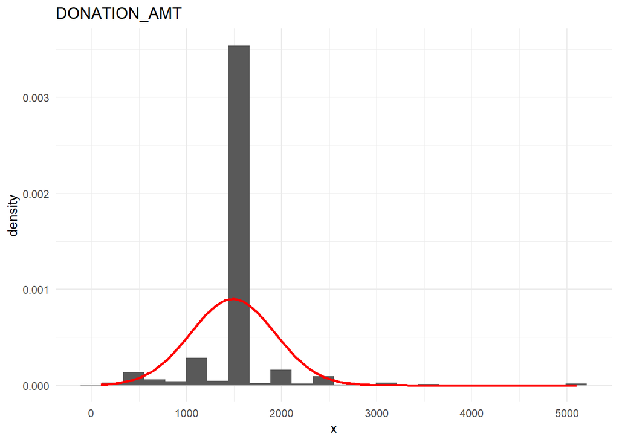

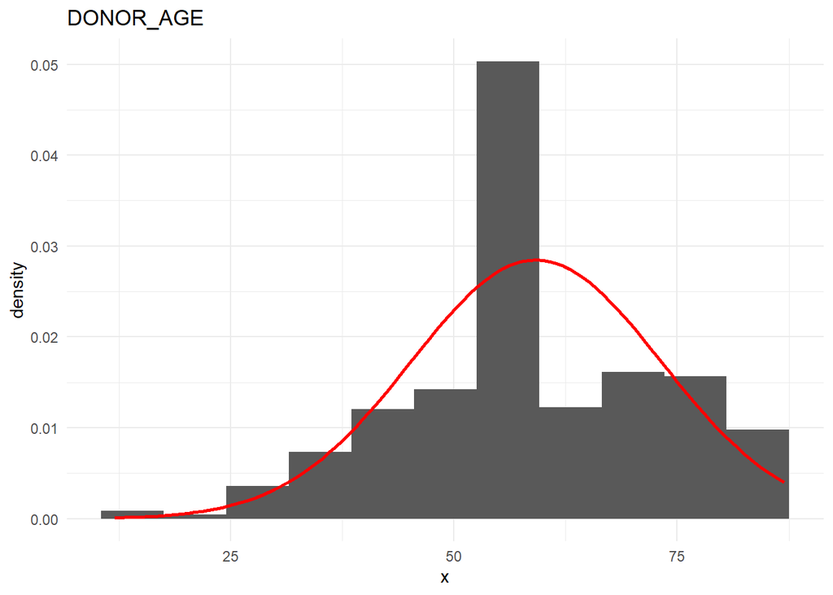

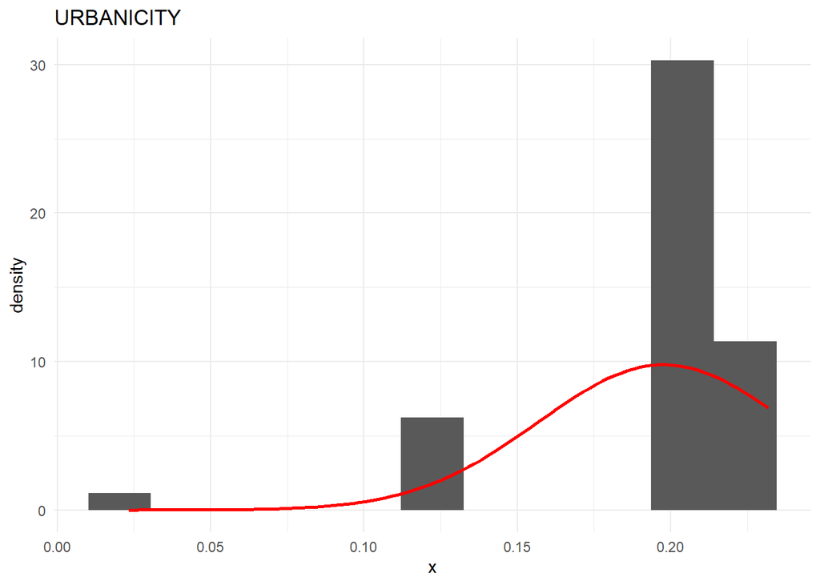

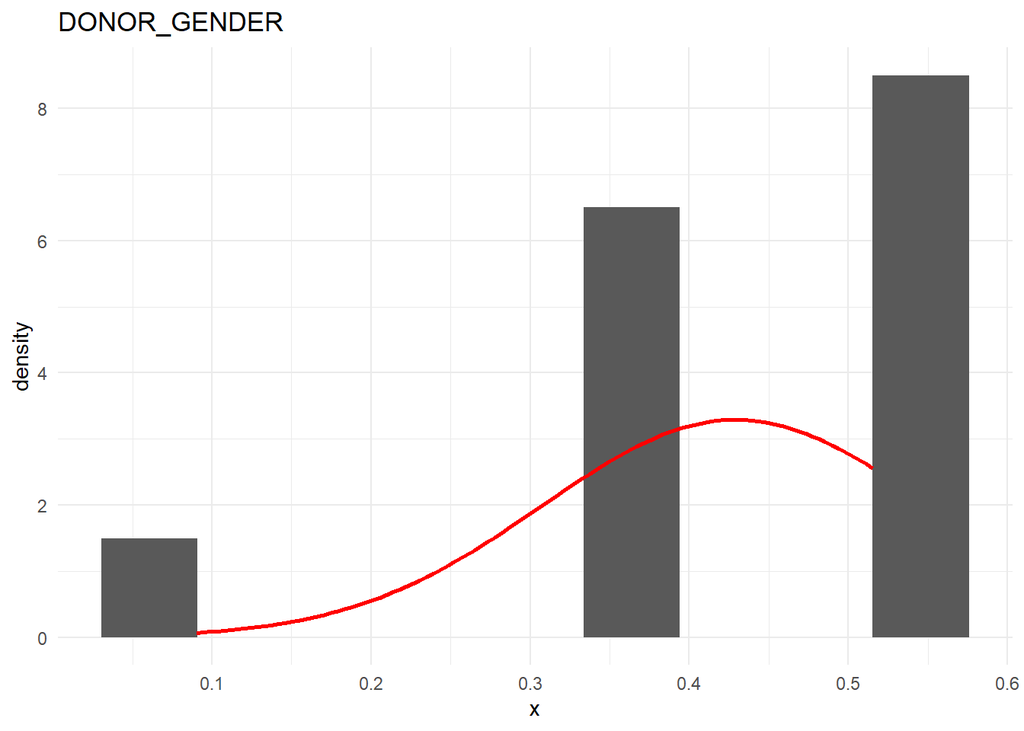

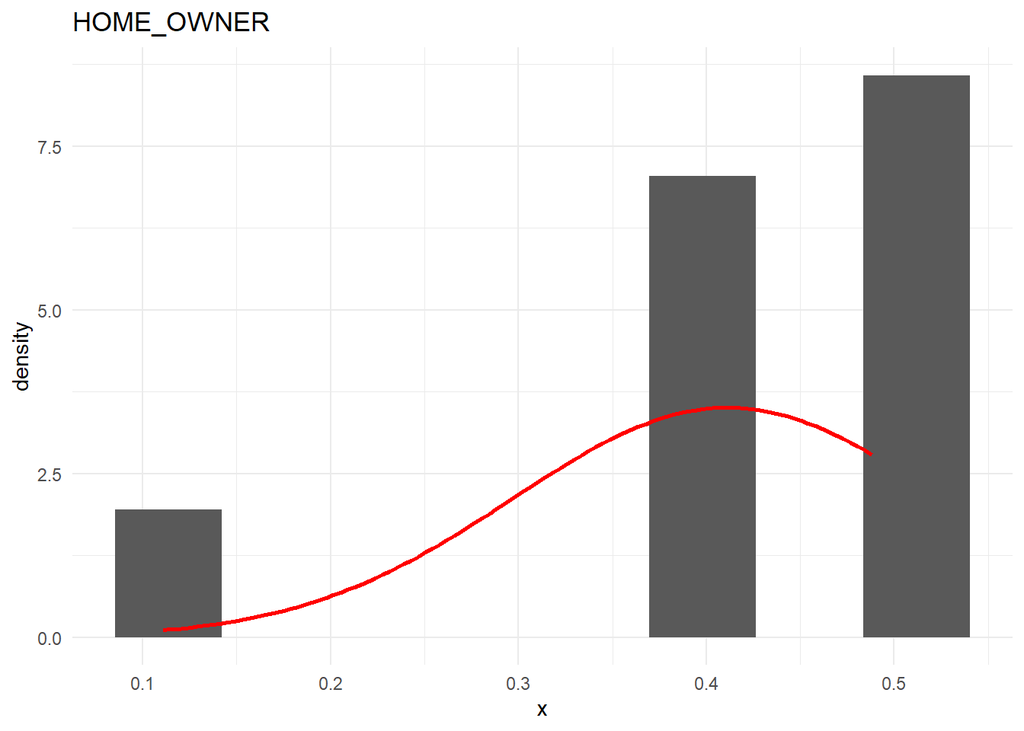

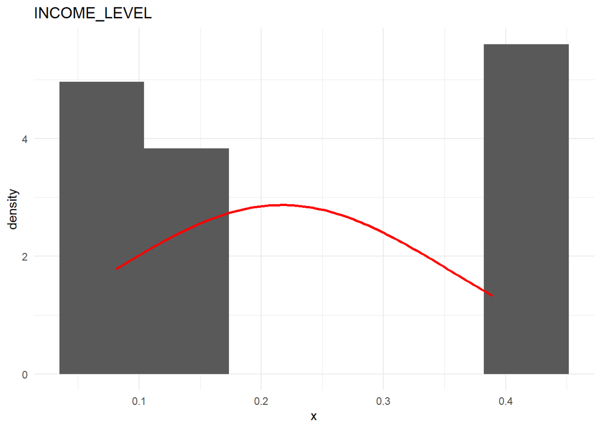

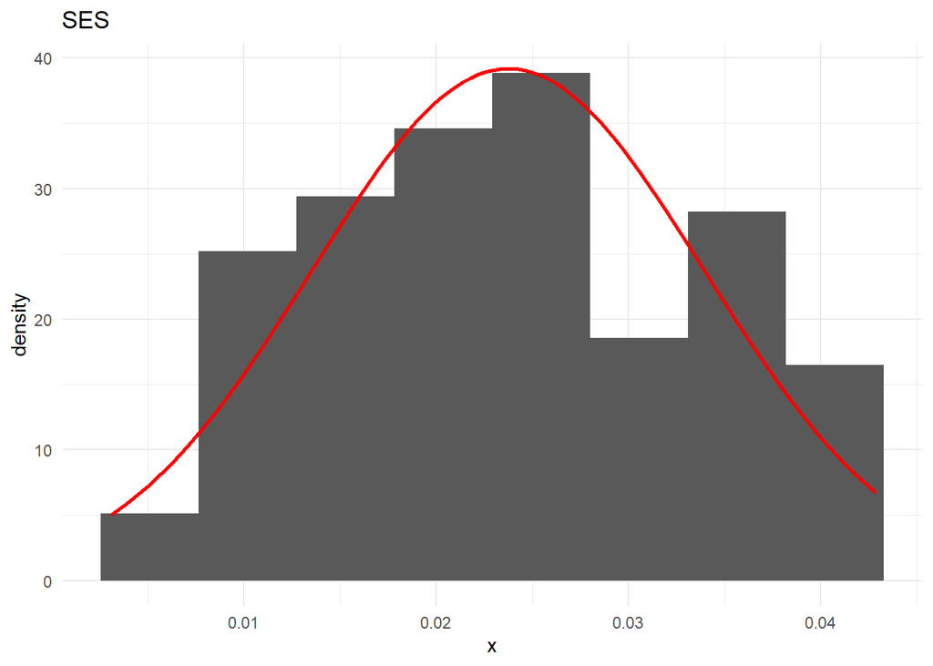

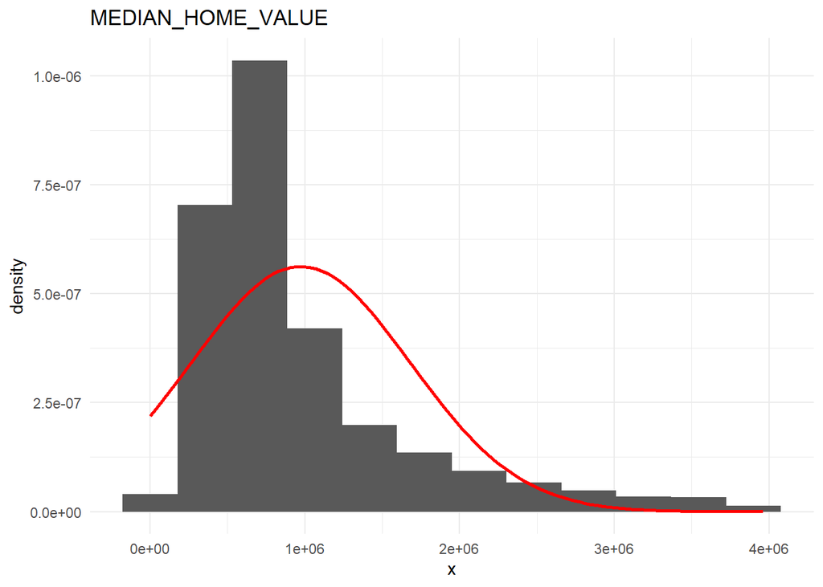

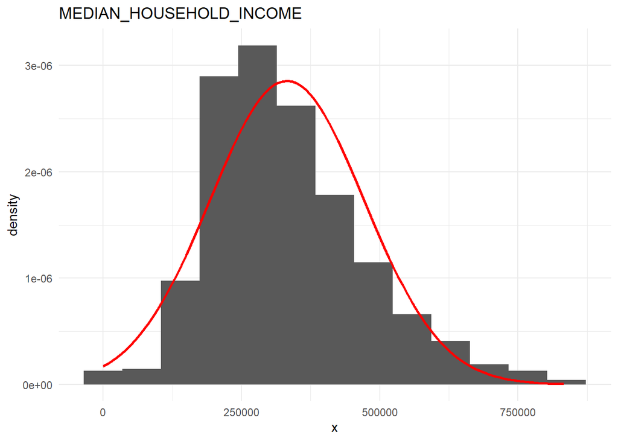

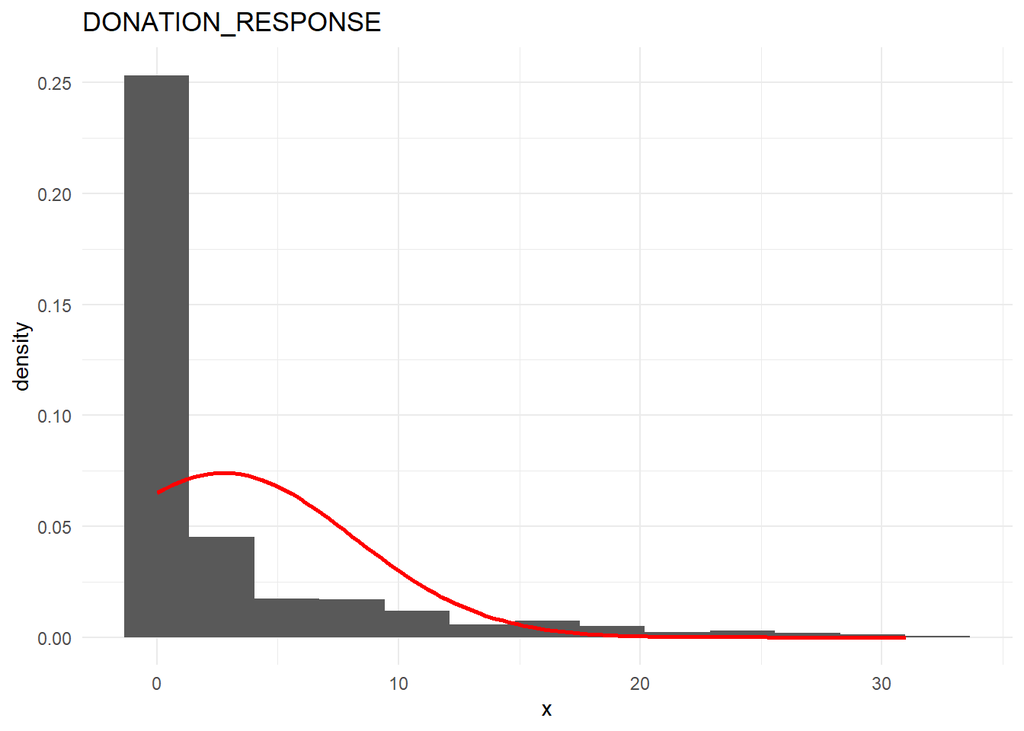

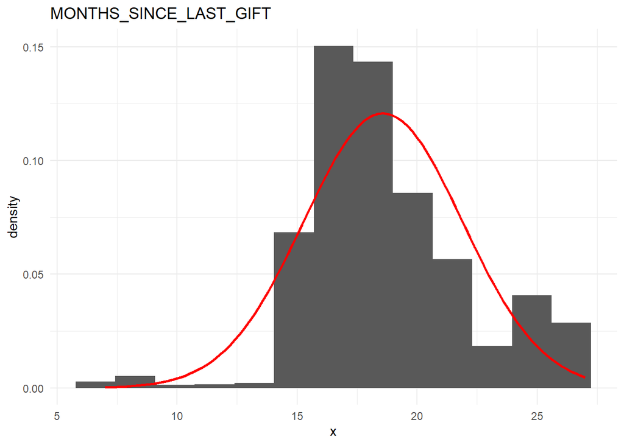

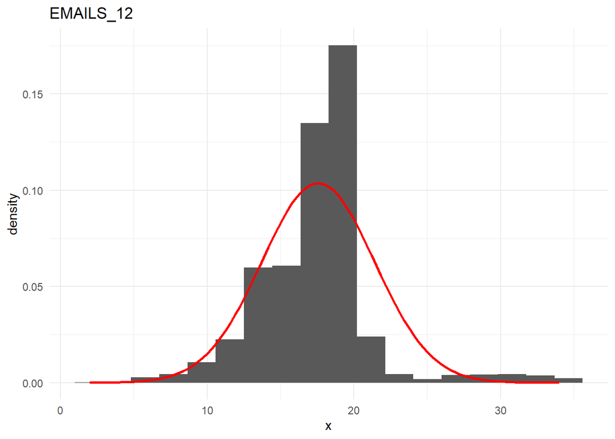

[6 more figures not shown]

```r
for (i in 1:ncol(df)) {
  # data column
  num_feat <- df[[i]]
  # numeric plotting with ggplot2 T.T
  np <- ggplot(data.frame(x = num_feat),
              aes(x)) +
    # set bin width to half the sd value of the feature so it is easier to visualize empirical rule
    geom_histogram(aes(y = ..density..),
                   binwidth = sd(num_feat, na.rm = T)/2) +
    stat_function(fun = dnorm,
                  args = list(mean = mean(num_feat, na.rm = T), sd = sd(num_feat, na.rm = T)),
                  color = "red",
                  size = 1) +
    ggtitle(colnames(df)[i]) +
    theme_minimal()

  print(np)
}
```